# Practical ML Project

# Project Details

Using devices such as Jawbone Up, Nike FuelBand, and Fitbit it is now possible to collect a large amount of data about personal activity relatively inexpensively. One thing that people regularly do is quantify how much of a particular activity they do, but they rarely quantify how well they do it. In this project, goal is to use data from accelerometers on the belt, forearm, arm, and dumbell of 6 participants. They were asked to perform barbell lifts correctly and incorrectly in 5 different ways.The data sources are provided in the r code. The training data set has the variable ‘classe’ that specifies how the activity was undertaken. Classe A is for the way an activity was specified to be correctly done.

#### Reading data from the source

```r
DataTrain<-read.csv(file="https://d396qusza40orc.cloudfront.net/predmachlearn/pml-training.csv")
DataTest<-read.csv(file="https://d396qusza40orc.cloudfront.net/predmachlearn/pml-testing.csv")
```

#### Looking at the structure of training and testing data

```r
str(DataTrain)
```

```
## 'data.frame':    19622 obs. of  160 variables:
##  $ X                       : int  1 2 3 4 5 6 7 8 9 10 ...
##  $ user_name               : Factor w/ 6 levels "adelmo","carlitos",..: 2 2 2 2 2 2 2 2 2 2 ...
##  $ raw_timestamp_part_1    : int  1323084231 1323084231 1323084231 1323084232 1323084232 1323084232 1323084232 1323084232 1323084232 1323084232 ...
##  $ raw_timestamp_part_2    : int  788290 808298 820366 120339 196328 304277 368296 440390 484323 484434 ...
##  $ cvtd_timestamp          : Factor w/ 20 levels "02/12/2011 13:32",..: 9 9 9 9 9 9 9 9 9 9 ...
##  $ new_window              : Factor w/ 2 levels "no","yes": 1 1 1 1 1 1 1 1 1 1 ...
##  $ num_window              : int  11 11 11 12 12 12 12 12 12 12 ...
##  $ roll_belt               : num  1.41 1.41 1.42 1.48 1.48 1.45 1.42 1.42 1.43 1.45 ...
##  $ pitch_belt              : num  8.07 8.07 8.07 8.05 8.07 8.06 8.09 8.13 8.16 8.17 ...
##  $ yaw_belt                : num  -94.4 -94.4 -94.4 -94.4 -94.4 -94.4 -94.4 -94.4 -94.4 -94.4 ...
##  $ total_accel_belt        : int  3 3 3 3 3 3 3 3 3 3 ...
##  $ kurtosis_roll_belt      : Factor w/ 397 levels "","-0.016850",..: 1 1 1 1 1 1 1 1 1 1 ...
##  $ kurtosis_picth_belt     : Factor w/ 317 levels "","-0.021887",..: 1 1 1 1 1 1 1 1 1 1 ...
##  $ kurtosis_yaw_belt       : Factor w/ 2 levels "","#DIV/0!": 1 1 1 1 1 1 1 1 1 1 ...
```

[output cut: 86 more lines]

```r
str(DataTest)
```

```
## 'data.frame':    20 obs. of  160 variables:
##  $ X                       : int  1 2 3 4 5 6 7 8 9 10 ...
##  $ user_name               : Factor w/ 6 levels "adelmo","carlitos",..: 6 5 5 1 4 5 5 5 2 3 ...
##  $ raw_timestamp_part_1    : int  1323095002 1322673067 1322673075 1322832789 1322489635 1322673149 1322673128 1322673076 1323084240 1322837822 ...
##  $ raw_timestamp_part_2    : int  868349 778725 342967 560311 814776 510661 766645 54671 916313 384285 ...
##  $ cvtd_timestamp          : Factor w/ 11 levels "02/12/2011 13:33",..: 5 10 10 1 6 11 11 10 3 2 ...
##  $ new_window              : Factor w/ 1 level "no": 1 1 1 1 1 1 1 1 1 1 ...
##  $ num_window              : int  74 431 439 194 235 504 485 440 323 664 ...
##  $ roll_belt               : num  123 1.02 0.87 125 1.35 -5.92 1.2 0.43 0.93 114 ...
##  $ pitch_belt              : num  27 4.87 1.82 -41.6 3.33 1.59 4.44 4.15 6.72 22.4 ...
##  $ yaw_belt                : num  -4.75 -88.9 -88.5 162 -88.6 -87.7 -87.3 -88.5 -93.7 -13.1 ...
##  $ total_accel_belt        : int  20 4 5 17 3 4 4 4 4 18 ...
##  $ kurtosis_roll_belt      : logi  NA NA NA NA NA NA ...
##  $ kurtosis_picth_belt     : logi  NA NA NA NA NA NA ...
##  $ kurtosis_yaw_belt       : logi  NA NA NA NA NA NA ...
```

[output cut: 86 more lines]

I have removed the columns with NA values both from training and testing data.

```r
DataTrainSub<-DataTrain[,colSums(is.na(DataTrain))==0]
DataTestSub<-DataTest[,colSums(is.na(DataTest))==0]
str(DataTrainSub)
str(DataTestSub)
```

Given the number of columns in training data are still more than those in the testing data, I have created data frame with common column names. Training data set will still have one more column, that is, the classe variable. The testing data had one extra column that has now been removed.

```r
nm=intersect(names(DataTrainSub),names(DataTestSub))

selectTrainData<-DataTrainSub[,which(names(DataTrainSub) %in% nm)]
selectTrainData<-cbind(selectTrainData,DataTrainSub$classe)
colnames(selectTrainData)[colnames(selectTrainData)=="DataTrainSub$classe"] <- "classe"

selectTestData<-DataTestSub[,which(names(DataTestSub) %in% nm)]

####Followig removes the first seven columns from both the data sets as these columns have factual data and do not appear to comprise of predictors.
selectTrainData<-selectTrainData[,-(1:7)]
selectTestData<-selectTestData[,-(1:7)]
```

#### I have now partitioned the training data into two separate data frames to enable setting up my model and validating the same.

```r
inTrain<-createDataPartition(selectTrainData$classe,p=0.7,list=FALSE)
SubTrain<-selectTrainData[inTrain,]
SubTest<-selectTrainData[-inTrain,]
```

```r
cluster <- makeCluster(detectCores() - 1)
registerDoParallel(cluster)
fitControl <- trainControl(method = "cv",
                           number = 5,
                           allowParallel = TRUE)
```

I will now be testing three models on the training data to arrive at the model that fits with maximum accuracy.The models employed are - classification tree, random forest and gradient boosting method

### Method: Classification Tree

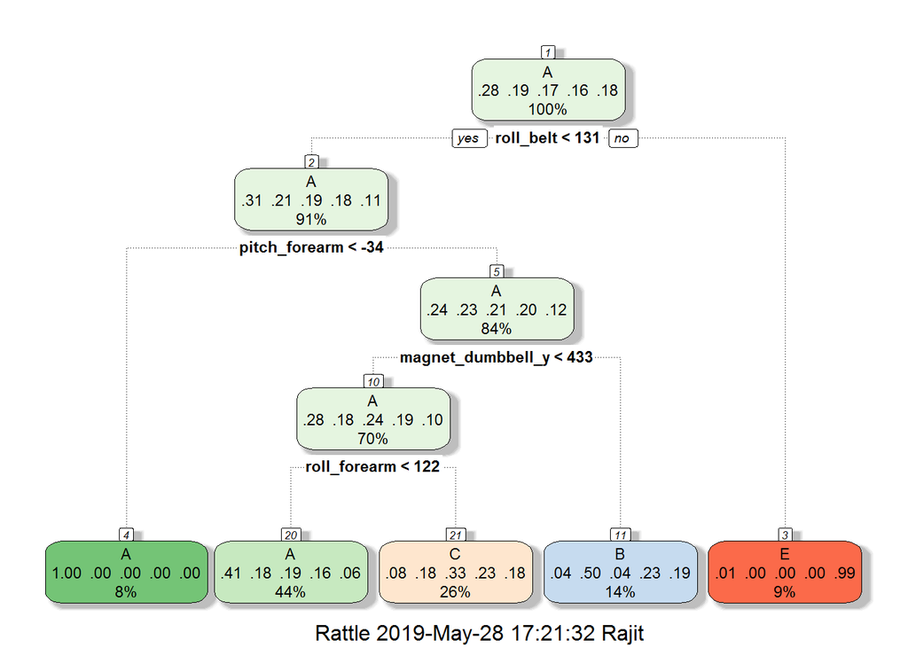

```r
fitrpart <- train(classe~.,method="rpart",data=SubTrain,trControl = fitControl)
save(fitrpart, file='./Modelrpart.RData')
fancyRpartPlot(fitrpart$finalModel)
```

```r
predRpart<-predict(fitrpart,newdata=SubTest)
confusionMatrix(SubTest$classe,predRpart)
```

```
## Confusion Matrix and Statistics
##
##           Reference
## Prediction    A    B    C    D    E
##          A 1508   32  129    0    5
##          B  455  388  296    0    0
##          C  443   44  539    0    0
##          D  418  171  375    0    0
##          E  159  144  309    0  470
##
## Overall Statistics
##
##                Accuracy : 0.4936
##                  95% CI : (0.4808, 0.5065)
##     No Information Rate : 0.5069
##     P-Value [Acc > NIR] : 0.9797
##
##                   Kappa : 0.3394
##
##  Mcnemar's Test P-Value : NA
##
## Statistics by Class:
##
##                      Class: A Class: B Class: C Class: D Class: E
## Sensitivity            0.5055  0.49807  0.32706       NA  0.98947
## Specificity            0.9428  0.85292  0.88506   0.8362  0.88688
## Pos Pred Value         0.9008  0.34065  0.52534       NA  0.43438
## Neg Pred Value         0.6497  0.91761  0.77176       NA  0.99896
## Prevalence             0.5069  0.13237  0.28003   0.0000  0.08071
## Detection Rate         0.2562  0.06593  0.09159   0.0000  0.07986
## Detection Prevalence   0.2845  0.19354  0.17434   0.1638  0.18386
## Balanced Accuracy      0.7242  0.67550  0.60606       NA  0.93817
```

### Method: Random Forest

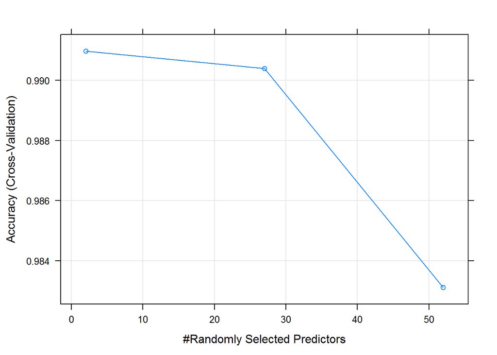

```r
fit <- train(classe~.,method="rf",data=SubTrain,trControl = fitControl)
save(fit, file='./Modelrf.RData')
plot(fit)
```

```r
predRF<-predict(fit,newdata=SubTest)
confusionMatrix(SubTest$classe,predRF)
```

```
## Confusion Matrix and Statistics
##
##           Reference
## Prediction    A    B    C    D    E
##          A 1673    1    0    0    0
##          B   10 1127    2    0    0
##          C    0    8 1018    0    0
##          D    0    0   21  943    0
##          E    0    0    3    0 1079
##
## Overall Statistics
##
##                Accuracy : 0.9924
##                  95% CI : (0.9898, 0.9944)
##     No Information Rate : 0.286
##     P-Value [Acc > NIR] : < 2.2e-16
##
##                   Kappa : 0.9903
##
##  Mcnemar's Test P-Value : NA
##
## Statistics by Class:
##
##                      Class: A Class: B Class: C Class: D Class: E
## Sensitivity            0.9941   0.9921   0.9751   1.0000   1.0000
## Specificity            0.9998   0.9975   0.9983   0.9958   0.9994
## Pos Pred Value         0.9994   0.9895   0.9922   0.9782   0.9972
## Neg Pred Value         0.9976   0.9981   0.9946   1.0000   1.0000
## Prevalence             0.2860   0.1930   0.1774   0.1602   0.1833
## Detection Rate         0.2843   0.1915   0.1730   0.1602   0.1833
## Detection Prevalence   0.2845   0.1935   0.1743   0.1638   0.1839
## Balanced Accuracy      0.9969   0.9948   0.9867   0.9979   0.9997
```

### Method: Gradient Boosting Method

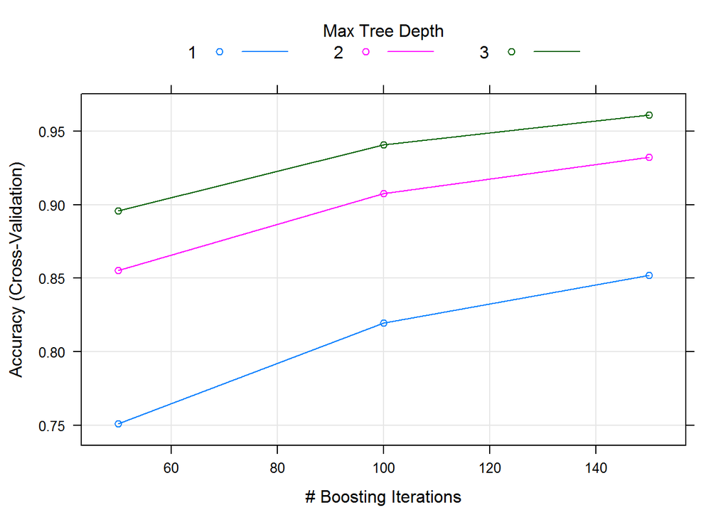

```r
fitgbm <- train(classe~.,method="gbm",data=SubTrain,trControl = fitControl,verbose=FALSE)
save(fitgbm, file='./Modelgbm.RData')
plot(fitgbm)
```

```r
predGBM<-predict(fitgbm,newdata=SubTest)
confusionMatrix(SubTest$classe, predGBM)
```

```
## Confusion Matrix and Statistics
##
##           Reference
## Prediction    A    B    C    D    E
##          A 1635   25    6    5    3
##          B   37 1080   21    1    0
##          C    0   43  968   14    1
##          D    5    2   40  910    7
##          E    2   11   12    6 1051
##
## Overall Statistics
##
##                Accuracy : 0.959
##                  95% CI : (0.9537, 0.964)
##     No Information Rate : 0.2853
##     P-Value [Acc > NIR] : < 2.2e-16
##
##                   Kappa : 0.9482
##
##  Mcnemar's Test P-Value : 3.556e-07
##
## Statistics by Class:
##
##                      Class: A Class: B Class: C Class: D Class: E
## Sensitivity            0.9738   0.9302   0.9245   0.9722   0.9896
## Specificity            0.9907   0.9875   0.9880   0.9891   0.9936
## Pos Pred Value         0.9767   0.9482   0.9435   0.9440   0.9713
## Neg Pred Value         0.9896   0.9829   0.9837   0.9947   0.9977
## Prevalence             0.2853   0.1973   0.1779   0.1590   0.1805
## Detection Rate         0.2778   0.1835   0.1645   0.1546   0.1786
## Detection Prevalence   0.2845   0.1935   0.1743   0.1638   0.1839
## Balanced Accuracy      0.9823   0.9589   0.9563   0.9807   0.9916
```

```r
stopCluster(cluster)
registerDoSEQ()
```

```r
TestPredictions <- predict(fit,newdata=selectTestData)
TestPredictions
```

```
##  [1] B A B A A E D B A A B C B A E E A B B B
## Levels: A B C D E
```